# CWM_Models

```r
emmeans(LDMC_CWM, pairwise ~ climate + treatment)
```

```
## $emmeans
##  climate      treatment emmean   SE  df asymp.LCL asymp.UCL
##  Arid         Open        30.0 3.77 Inf      22.6      37.4
##  Intermediate Open        41.0 3.77 Inf      33.6      48.4
##  Mesic        Open        27.0 3.77 Inf      19.6      34.4
##  Arid         Partial     24.1 3.77 Inf      16.7      31.5
##  Intermediate Partial     35.1 3.77 Inf      27.7      42.5
##  Mesic        Partial     21.1 3.77 Inf      13.7      28.5
##  Arid         Total       37.6 3.77 Inf      30.2      45.0
##  Intermediate Total       48.6 3.77 Inf      41.2      56.0
##  Mesic        Total       34.6 3.77 Inf      27.2      42.0
##
## Confidence level used: 0.95
##
## $contrasts
##  contrast                                  estimate   SE  df z.ratio p.value
##  Arid,Open - Intermediate,Open              -10.978 4.13 Inf -2.655  0.1642
##  Arid,Open - Mesic,Open                       3.040 4.13 Inf  0.735  0.9983
##  Arid,Open - Arid,Partial                     5.896 4.13 Inf  1.426  0.8881
##  Arid,Open - Intermediate,Partial            -5.082 5.85 Inf -0.869  0.9945
##  Arid,Open - Mesic,Partial                    8.936 5.85 Inf  1.528  0.8426
##  Arid,Open - Arid,Total                      -7.611 4.13 Inf -1.841  0.6548
##  Arid,Open - Intermediate,Total             -18.590 5.85 Inf -3.179  0.0396
##  Arid,Open - Mesic,Total                     -4.572 5.85 Inf -0.782  0.9974
##  Intermediate,Open - Mesic,Open              14.018 4.13 Inf  3.390  0.0201
##  Intermediate,Open - Arid,Partial            16.875 5.85 Inf  2.886  0.0921
##  Intermediate,Open - Intermediate,Partial     5.896 4.13 Inf  1.426  0.8881
##  Intermediate,Open - Mesic,Partial           19.914 5.85 Inf  3.406  0.0191
##  Intermediate,Open - Arid,Total               3.367 5.85 Inf  0.576  0.9997
##  Intermediate,Open - Intermediate,Total      -7.611 4.13 Inf -1.841  0.6548
##  Intermediate,Open - Mesic,Total              6.407 5.85 Inf  1.096  0.9750
##  Mesic,Open - Arid,Partial                    2.856 5.85 Inf  0.488  0.9999
##  Mesic,Open - Intermediate,Partial           -8.122 5.85 Inf -1.389  0.9024
##  Mesic,Open - Mesic,Partial                   5.896 4.13 Inf  1.426  0.8881
##  Mesic,Open - Arid,Total                    -10.651 5.85 Inf -1.821  0.6679
##  Mesic,Open - Intermediate,Total            -21.629 5.85 Inf -3.699  0.0067
##  Mesic,Open - Mesic,Total                    -7.611 4.13 Inf -1.841  0.6548
##  Arid,Partial - Intermediate,Partial        -10.978 4.13 Inf -2.655  0.1642
##  Arid,Partial - Mesic,Partial                 3.040 4.13 Inf  0.735  0.9983
##  Arid,Partial - Arid,Total                  -13.507 4.13 Inf -3.267  0.0301
##  Arid,Partial - Intermediate,Total          -24.486 5.85 Inf -4.187  0.0009
##  Arid,Partial - Mesic,Total                 -10.468 5.85 Inf -1.790  0.6889
##  Intermediate,Partial - Mesic,Partial        14.018 4.13 Inf  3.390  0.0201
##  Intermediate,Partial - Arid,Total           -2.529 5.85 Inf -0.432  1.0000
##  Intermediate,Partial - Intermediate,Total  -13.507 4.13 Inf -3.267  0.0301
##  Intermediate,Partial - Mesic,Total           0.511 5.85 Inf  0.087  1.0000
##  Mesic,Partial - Arid,Total                 -16.547 5.85 Inf -2.830  0.1067
##  Mesic,Partial - Intermediate,Total         -27.526 5.85 Inf -4.707  0.0001
##  Mesic,Partial - Mesic,Total                -13.507 4.13 Inf -3.267  0.0301
##  Arid,Total - Intermediate,Total            -10.978 4.13 Inf -2.655  0.1642
##  Arid,Total - Mesic,Total                     3.040 4.13 Inf  0.735  0.9983
##  Intermediate,Total - Mesic,Total            14.018 4.13 Inf  3.390  0.0201
##
## P value adjustment: tukey method for comparing a family of 9 estimates
```

```
## Comparison discrepancy in group 1, Partial,Arid - Total,Arid:
##     Target overlap = -0.0532, overlap on graph = 0.0996
```

```
## Comparison discrepancy in group 1, Partial,Arid - Open,Intermediate:
##     Target overlap = 0.0696, overlap on graph = -0.0563
```

```
## Comparison discrepancy in group 1, Total,Arid - Partial,Mesic:
##     Target overlap = 0.0877, overlap on graph = -0.0305
```

```
## Comparison discrepancy in group 1, Open,Intermediate - Open,Mesic:
##     Target overlap = -0.093, overlap on graph = 0.0544
```

```
## Comparison discrepancy in group 1, Partial,Mesic - Total,Mesic:
##     Target overlap = -0.0532, overlap on graph = 0.0284
```

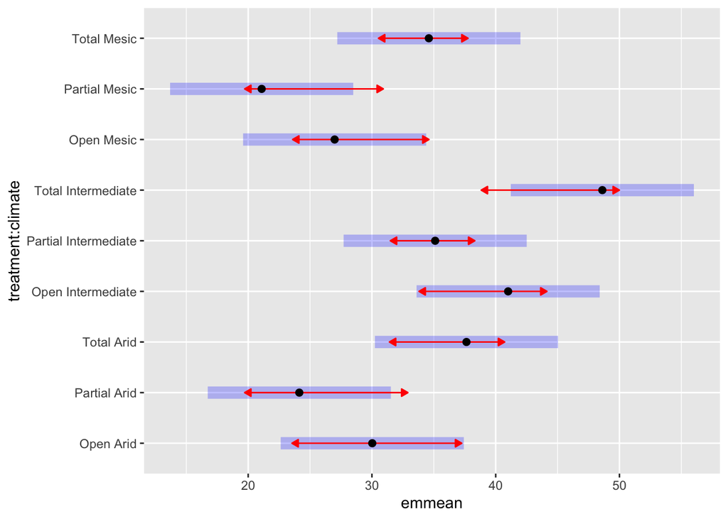

```r
plot(emmeans(LDMC_CWM, pairwise ~ treatment + climate), comparisons = TRUE)
```

```r
multcomp::cld(emmeans(LDMC_CWM, ~ treatment), alpha = 0.05, Letters = LETTERS)
```

```
##  treatment emmean   SE  df asymp.LCL asymp.UCL .group
##  Partial     26.8 2.92 Inf      21.0      32.5  A
##  Open        32.7 2.92 Inf      26.9      38.4  AB
##  Total       40.3 2.92 Inf      34.6      46.0   B
##
## Results are averaged over the levels of: climate
## Confidence level used: 0.95
## P value adjustment: tukey method for comparing a family of 3 estimates
## significance level used: alpha = 0.05
```

#### d. Seed mass CWM

- same trend observed across climates
- same trend observed across herbivore treatments -Arid
  - Arid-Total > Arid-Open
  - No difference between Arid-Open and Arid-Partial
  - No difference between Arid-Partial and Arid-Total
- Int -Int-Total > Int-Open
  - No difference between Int-Open and Int-Partial
  - No difference between Int-Partial and Int-Total
- Mesic -Mesic-Total > Mesic-Open
  - No difference between Mesic-Open and Mesic-Partial
  - No difference between Mesic-Partial and Mesic-Total
- Open:
  - Int Open > Mesic-Open
  - No difference between Arid and Mesic
- Partial:
  - Int-Partial > Mesic-Partial
  - No difference between Arid and Mesic
- Total:
  - Int-Total > Mesic-Total
  - No difference between Arid and Mesic

```r
# seed_mass_CWM <- glm(data = cwm_traits_adj, weighted_seed_mass ~ climate * treatment, family = gaussian, na.action = na.fail)
# dredge(seed_mass_CWM) #best model: weighted_seed_mass ~ cliamte + treatment
# seed_mass_CWM <- glm(data = cwm_traits_adj, weighted_seed_mass ~ climate + treatment, family = gaussian, na.action = na.fail)

# simulateResiduals(seed_mass_CWM, plot= T) #model predictions look a little wonky, but it says it's good.  I'm also getting something saying that "outer Newton did not converge fully?
# shapiro.test(residuals(seed_mass_CWM)) # not normal

# log transformation
log_seed_mass <- glm(data = cwm_traits_adj, log_seed_mass ~ climate * treatment, family = gaussian, na.action = na.fail)
dredge(log_seed_mass) #best model: weighted_seed_mass ~ cliamte + treatment
```

```
## Fixed term is "(Intercept)"
```

```
## Global model call: glm(formula = log_seed_mass ~ climate * treatment, family = gaussian,
##     data = cwm_traits_adj, na.action = na.fail)
## ---
## Model selection table
##     (Int) clm trt clm:trt df  logLik AICc delta weight
## 4 -1.0810   +   +          6  -8.024 32.2  0.00  0.967
## 2 -0.7418   +              4 -15.158 40.1  7.89  0.019
## 8 -1.1520   +   +       + 10  -3.751 41.3  9.00  0.011
## 3 -1.1620       +          4 -17.152 44.1 11.87  0.003
## 1 -0.8230                  2 -21.244 47.0 14.74  0.001
## Models ranked by AICc(x)
```

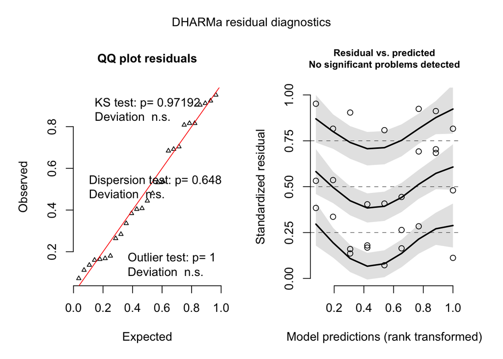

```
## Object of Class DHARMa with simulated residuals based on 250 simulations with refit = FALSE . See ?DHARMa::simulateResiduals for help.
##
## Scaled residual values: 0.16 0.136 0.904 0.164 0.264 0.444 0.704 0.912 0.684 0.808 0.072 0.408 0.284 0.924 0.692 0.48 0.112 0.816 0.532 0.384 ...
```

```r
log_seed_mass <- glm(data = cwm_traits_adj, log_seed_mass ~ climate + treatment, family = gaussian, na.action = na.fail)

simulateResiduals(log_seed_mass, plot= T) #looks ok
```

```r
shapiro.test(residuals(log_seed_mass)) #normal
```

```
##
##  Shapiro-Wilk normality test
##
## data:  residuals(log_seed_mass)
## W = 0.95871, p-value = 0.3453
```

```r
#pairwise comparisons
seed_sig_pairs <-  as.data.frame(pairs(emmeans(log_seed_mass, ~ climate + treatment))) %>%
  filter(p.value <= 0.05)

emmeans(log_seed_mass, pairwise ~ climate)
```

```
## $emmeans
##  climate      emmean   SE  df asymp.LCL asymp.UCL
##  Arid         -0.742 0.12 Inf    -0.978    -0.506
##  Intermediate -0.478 0.12 Inf    -0.714    -0.242
##  Mesic        -1.249 0.12 Inf    -1.485    -1.014
##
## Results are averaged over the levels of: treatment
## Confidence level used: 0.95
##
## $contrasts
##  contrast             estimate   SE  df z.ratio p.value
##  Arid - Intermediate    -0.264 0.17 Inf -1.552  0.2669
##  Arid - Mesic            0.508 0.17 Inf  2.984  0.0080
##  Intermediate - Mesic    0.772 0.17 Inf  4.536  <.0001
##
## Results are averaged over the levels of: treatment
## P value adjustment: tukey method for comparing a family of 3 estimates
```

```r
emmeans(log_seed_mass, pairwise ~ treatment)
```

```
## $emmeans
##  treatment emmean   SE  df asymp.LCL asymp.UCL
##  Open      -1.162 0.12 Inf    -1.398    -0.926
##  Partial   -0.810 0.12 Inf    -1.046    -0.574
##  Total     -0.497 0.12 Inf    -0.732    -0.261
##
## Results are averaged over the levels of: climate
## Confidence level used: 0.95
##
## $contrasts
##  contrast        estimate   SE  df z.ratio p.value
##  Open - Partial    -0.352 0.17 Inf -2.069  0.0964
##  Open - Total      -0.665 0.17 Inf -3.912  0.0003
##  Partial - Total   -0.314 0.17 Inf -1.843  0.1557
##
## Results are averaged over the levels of: climate
## P value adjustment: tukey method for comparing a family of 3 estimates
```

```r
emmeans(log_seed_mass, pairwise ~ climate + treatment)
```

```
## $emmeans
##  climate      treatment emmean    SE  df asymp.LCL asymp.UCL
##  Arid         Open      -1.081 0.155 Inf    -1.385    -0.777
##  Intermediate Open      -0.817 0.155 Inf    -1.121    -0.513
##  Mesic        Open      -1.588 0.155 Inf    -1.893    -1.284
##  Arid         Partial   -0.729 0.155 Inf    -1.033    -0.425
##  Intermediate Partial   -0.465 0.155 Inf    -0.769    -0.161
##  Mesic        Partial   -1.237 0.155 Inf    -1.541    -0.932
##  Arid         Total     -0.415 0.155 Inf    -0.720    -0.111
##  Intermediate Total     -0.152 0.155 Inf    -0.456     0.153
##  Mesic        Total     -0.923 0.155 Inf    -1.227    -0.619
##
## Confidence level used: 0.95
##
## $contrasts
##  contrast                                  estimate    SE  df z.ratio p.value
##  Arid,Open - Intermediate,Open              -0.2640 0.170 Inf -1.552  0.8307
##  Arid,Open - Mesic,Open                      0.5076 0.170 Inf  2.984  0.0703
##  Arid,Open - Arid,Partial                   -0.3519 0.170 Inf -2.069  0.4950
##  Arid,Open - Intermediate,Partial           -0.6158 0.241 Inf -2.560  0.2037
##  Arid,Open - Mesic,Partial                   0.1557 0.241 Inf  0.647  0.9993
##  Arid,Open - Arid,Total                     -0.6654 0.170 Inf -3.912  0.0030
##  Arid,Open - Intermediate,Total             -0.9293 0.241 Inf -3.863  0.0036
##  Arid,Open - Mesic,Total                    -0.1578 0.241 Inf -0.656  0.9993
##  Intermediate,Open - Mesic,Open              0.7715 0.170 Inf  4.536  0.0002
##  Intermediate,Open - Arid,Partial           -0.0879 0.241 Inf -0.365  1.0000
##  Intermediate,Open - Intermediate,Partial   -0.3519 0.170 Inf -2.069  0.4950
##  Intermediate,Open - Mesic,Partial           0.4196 0.241 Inf  1.745  0.7188
##  Intermediate,Open - Arid,Total             -0.4014 0.241 Inf -1.669  0.7658
##  Intermediate,Open - Intermediate,Total     -0.6654 0.170 Inf -3.912  0.0030
##  Intermediate,Open - Mesic,Total             0.1061 0.241 Inf  0.441  1.0000
##  Mesic,Open - Arid,Partial                  -0.8594 0.241 Inf -3.573  0.0107
##  Mesic,Open - Intermediate,Partial          -1.1234 0.241 Inf -4.670  0.0001
##  Mesic,Open - Mesic,Partial                 -0.3519 0.170 Inf -2.069  0.4950
##  Mesic,Open - Arid,Total                    -1.1729 0.241 Inf -4.876  <.0001
##  Mesic,Open - Intermediate,Total            -1.4369 0.241 Inf -5.973  <.0001
##  Mesic,Open - Mesic,Total                   -0.6654 0.170 Inf -3.912  0.0030
##  Arid,Partial - Intermediate,Partial        -0.2640 0.170 Inf -1.552  0.8307
##  Arid,Partial - Mesic,Partial                0.5076 0.170 Inf  2.984  0.0703
##  Arid,Partial - Arid,Total                  -0.3135 0.170 Inf -1.843  0.6531
##  Arid,Partial - Intermediate,Total          -0.5775 0.241 Inf -2.401  0.2834
##  Arid,Partial - Mesic,Total                  0.1940 0.241 Inf  0.807  0.9967
##  Intermediate,Partial - Mesic,Partial        0.7715 0.170 Inf  4.536  0.0002
##  Intermediate,Partial - Arid,Total          -0.0496 0.241 Inf -0.206  1.0000
##  Intermediate,Partial - Intermediate,Total  -0.3135 0.170 Inf -1.843  0.6531
##  Intermediate,Partial - Mesic,Total          0.4580 0.241 Inf  1.904  0.6110
##  Mesic,Partial - Arid,Total                 -0.8211 0.241 Inf -3.413  0.0186
##  Mesic,Partial - Intermediate,Total         -1.0850 0.241 Inf -4.511  0.0002
##  Mesic,Partial - Mesic,Total                -0.3135 0.170 Inf -1.843  0.6531
##  Arid,Total - Intermediate,Total            -0.2640 0.170 Inf -1.552  0.8307
##  Arid,Total - Mesic,Total                    0.5076 0.170 Inf  2.984  0.0703
##  Intermediate,Total - Mesic,Total            0.7715 0.170 Inf  4.536  0.0002
##
## P value adjustment: tukey method for comparing a family of 9 estimates
```

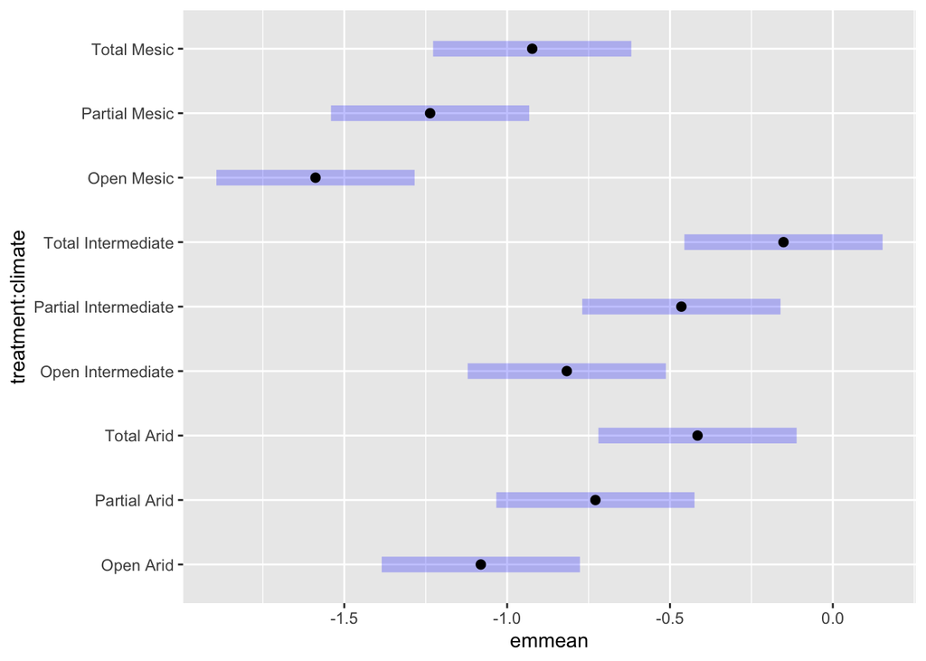

```r
plot(emmeans(log_seed_mass, pairwise ~ treatment + climate))
```

```r
multcomp::cld(emmeans(log_seed_mass, ~ treatment), alpha = 0.05, Letters = LETTERS)
```

```
##  treatment emmean   SE  df asymp.LCL asymp.UCL .group
##  Open      -1.162 0.12 Inf    -1.398    -0.926  A
##  Partial   -0.810 0.12 Inf    -1.046    -0.574  AB
##  Total     -0.497 0.12 Inf    -0.732    -0.261   B
##
## Results are averaged over the levels of: climate
## Confidence level used: 0.95
## P value adjustment: tukey method for comparing a family of 3 estimates
## significance level used: alpha = 0.05
```